# Group lab exercise 🏆

## Group Details

### Group Member 1

- Name: Aqilah Rafidi
- Student ID: 22B2149
- Favourite book: Tomie by Junji Ito
- Favourite number: 14
- Favourite mathematical equation: **$a^2+b^2=c^2$**
- Insert an inspiring photo:

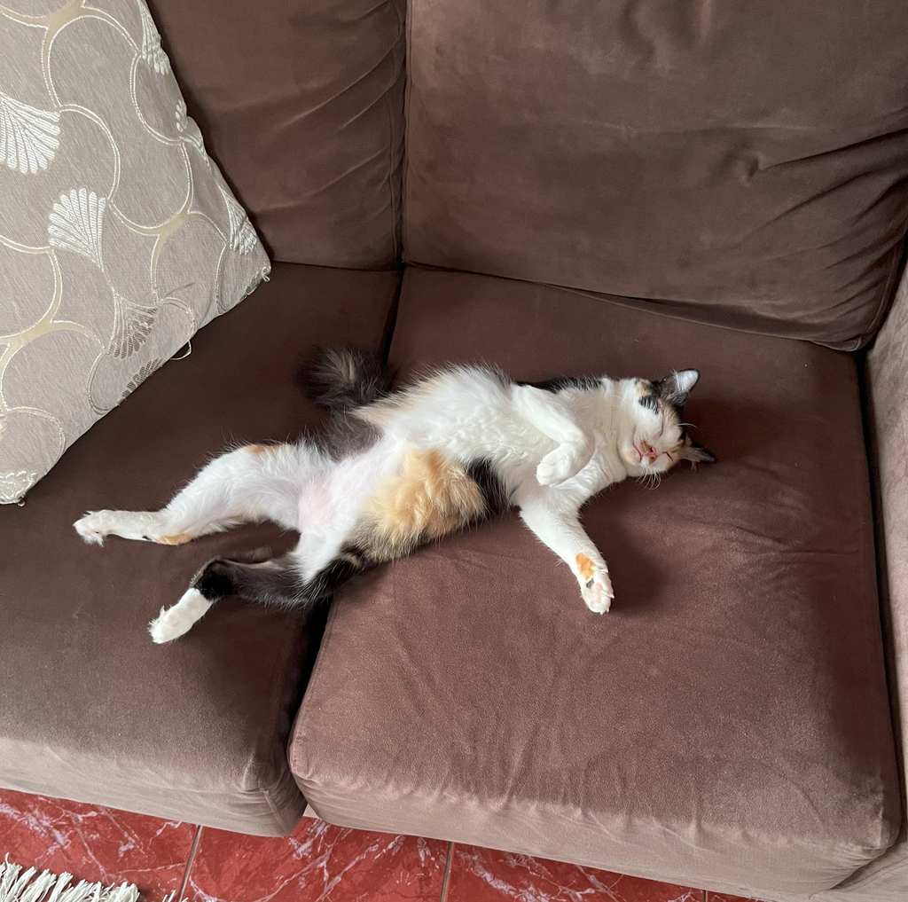

### Group Member 2

- Name: Izznie Adanan
- Student ID: 22B2125
- Favourite book: Reel by Kennedy Ryan
- Favourite number: 22
- Favourite mathematical equation: **$tan\theta= \frac{sin\theta}{cos\theta}$**
- Insert an inspiring photo:

[figure not shown]

### Group Member 3

- Name: Syafiqah Raddin
- Student ID: 22b2046
- Favourite book: Ikigai
- Favourite number: 213
- Favourite mathematical equation: **$x = \frac {-b \pm \sqrt{b^2 -4ac}} {2a}$**
- Insert an inspiring photo:

[figure not shown]

### Group Member 4

- Name: Bibi Junaidi
- Student ID: 22B9014
- Favourite book: Atomic Habit / Crying in H Mart
- Favourite number: 810
- Favourite mathematical equation: **$y=mx + c$**
- Insert an inspiring photo:

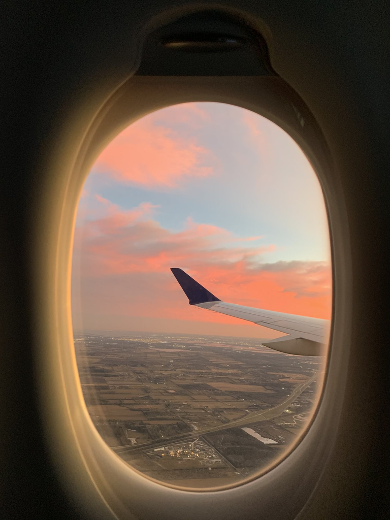

## Collaborative Work

#### ggsave()

1. Description: `ggsave()` is a convenient function for saving a plot. It defaults to saving the last plot that you displayed, using the size of the current graphics device. It also guesses the type of graphics device from the extension.
2. Usage:

```
ggsave(
  filename,
  plot = last_plot(),
  device = NULL,
  path = NULL,
  scale = 1,
  width = NA,
  height = NA,
  units = c("in", "cm", "mm", "px"),
  dpi = 300,
  limitsize = TRUE,
  bg = NULL,
  ...
)
```

3. Details: Note: Filenames with page numbers can be generated by including a C integer format expression, such as %03d (as in the default file name for most R graphics devices, see e.g. png()). Thus, filename = “figure%03d.png” will produce successive filenames figure001.png, figure002.png, figure003.png, etc. To write a filename containing the % sign, use %%. For example, filename = “figure-100%%.png” will produce the filename figure-100%.png.
4. Examples

```
if (FALSE) {
ggplot(mtcars, aes(mpg, wt)) +
  geom_point()

ggsave("mtcars.pdf")
ggsave("mtcars.png")

ggsave("mtcars.pdf", width = 4, height = 4)
ggsave("mtcars.pdf", width = 20, height = 20, units = "cm")

# delete files with base::unlink()
unlink("mtcars.pdf")
unlink("mtcars.png")

# specify device when saving to a file with unknown extension
# (for example a server supplied temporary file)
file <- tempfile()
ggsave(file, device = "pdf")
unlink(file)

# save plot to file without using ggsave
p <-
  ggplot(mtcars, aes(mpg, wt)) +
  geom_point()
png("mtcars.png")
print(p)
dev.off()

}
```

##### Use of arguments width and height in ggsave()

- The arguments width and height are used to resize a plot or an image to a desired size, so using ggsave() can save it as the new resized version.